# Prediction with regression (2)

Jose M Sallan

09/04/2020

# 1 Insurance data

To illustrate how can we use linear regression to predict a numerical variable, we will use a dataset of insurance charges provided by professor Eric Suess. The dataset contains insurance charges from customers of a medical insurance company, together with variables describing each customer:

https://www.kaggle.com/noordeen/insurance-premium-prediction

The dataset is wrapped in BAdatasets package under the name InsuranceCharges. Let’s name it insurance:

```r
library(BAdatasets)
insurance <- InsuranceCharges
```

And let’s examine the data:

```r
library(skimr)
skim(insurance)
```

Data summary

| Name | insurance |
| --- | --- |
| Number of rows | 1338 |
| Number of columns | 7 |
| _______________________ |  |
| Column type frequency: |  |
| factor | 3 |
| numeric | 4 |
| ________________________ |  |
| Group variables | None |

**Variable type: factor**

| skim_variable | n_missing | complete_rate | ordered | n_unique | top_counts |
| --- | --- | --- | --- | --- | --- |
| sex | 0 | 1 | FALSE | 2 | mal: 676, fem: 662 |
| smoker | 0 | 1 | FALSE | 2 | no: 1064, yes: 274 |
| region | 0 | 1 | FALSE | 4 | sou: 364, nor: 325, sou: 325, nor: 324 |

**Variable type: numeric**

| skim_variable | n_missing | complete_rate | mean | sd | p0 | p25 | p50 | p75 | p100 | hist |
| --- | --- | --- | --- | --- | --- | --- | --- | --- | --- | --- |
| age | 0 | 1 | 39.21 | 14.05 | 18.00 | 27.00 | 39.00 | 51.00 | 64.00 | ▇▅▅▆▆ |
| bmi | 0 | 1 | 30.66 | 6.10 | 15.96 | 26.30 | 30.40 | 34.69 | 53.13 | ▂▇▇▂▁ |
| children | 0 | 1 | 1.09 | 1.21 | 0.00 | 0.00 | 1.00 | 2.00 | 5.00 | ▇▂▂▁▁ |
| charges | 0 | 1 | 13270.42 | 12110.01 | 1121.87 | 4740.29 | 9382.03 | 16639.91 | 63770.43 | ▇▂▁▁▁ |

The dataset contains three factor variables:

- `sex` for gender
- `smoker` indicating if the customer smokes or not
- the `region` the customer comes from

and three numerical variables:

- `age`
- the body mass index `bmi` (see https://en.wikipedia.org/wiki/Body_mass_index)
- number of `children`

The variable to predict is `charges`, which is also numeric.

As people with a bmi equal or larger than 30 are considered obese, we will create a factor variable `bmi30` equal to one if `bmi` is equal or larger than 30, and zero otherwise.

```r
library(tidyverse)
insurance <- insurance %>% mutate(bmi30 = as.factor(ifelse(insurance$bmi >= 30, 1, 0)))
```

# 2 Predicting with regression using `caret`

We will use caret to apply linear regression to this dataset, so we can create the data partition and assess model performance.

```r
library(caret)
```

## 2.1 Data partition

Data partition is created from the variable to predict. Here we put 80% of the dataset into train set `insurance_train`, and the rest in test set `insurance_test`.

```r
set.seed(1111)
inTrain <- createDataPartition(insurance$charges, p=0.8, list=FALSE)
insurance_train <- insurance[inTrain, ]
insurance_test <- insurance[-inTrain, ]
```

## 2.2 First models

Let’s build a first model `mod01` with some variables. The predictions of the model on the train set are in `pr_train01`. Note that we have centered and scaled variables for a better processing:

```r
mod01 <- train(charges ~ age + smoker, insurance_train, method="lm", preProcess=c("center", "scale"))
pr_train01 <- predict(mod01, insurance_train)
```

We assess model performance on the train test with postResample:

```r
postResample(pred = pr_train01, insurance_train$charges)
```

```
##         RMSE     Rsquared          MAE
## 6221.5789524    0.7315435 3977.4349498
```

Let’s add the rest of variables into the model, and see if that improves prediction:

```r
mod02 <- train(charges ~ sex + smoker + region + age + bmi + children, method="lm", insurance_train, preProcess=c("center", "scale"))
pr_train02 <- predict(mod02, insurance_train)
postResample(pred = pr_train02, insurance_train$charges)
```

```
##         RMSE     Rsquared          MAE
## 5849.0396307    0.7627305 4043.6592623
```

## 2.3 Adding a quadratic term

Sometimes the prediction can improve if we add powered values (squared, cubed, etc.) of some variables. To do so, it is convenient to center variables, as we are doing. Here we will add a squared term for `age`:

There are two ways of adding polynomial terms.

- Inserting in the formula of `lm` something like `age + I(age^2)`
- Inserting in the formula of `lm` something like `poly(age, 2)`

The second way inserts orthogonal polynomials, so that they are uncorrelated and we can appreciate the effect of each variable better. In prediction tasks both methods lead to the same values of prediction.

```r
mod03 <- train(charges ~ sex + smoker + region + poly(age, 2) + bmi + children, method="lm", insurance_train, preProcess=c("center", "scale"))
```

Let’s see how the model looks like:

```r
summary(mod03$finalModel)
```

```
##
## Call:
## lm(formula = .outcome ~ ., data = dat)
##
## Residuals:
##      Min       1Q   Median       3Q      Max
## -11689.0  -2742.7   -815.4   1413.3  30586.2
##
## Coefficients:
##                 Estimate Std. Error t value Pr(>|t|)
## (Intercept)      13229.2      178.6  74.077  < 2e-16 ***
## sexmale           -125.2      179.7  -0.697 0.486079
## smokeryes         9770.5      180.1  54.245  < 2e-16 ***
## regionnorthwest   -274.2      221.1  -1.240 0.215148
## regionsoutheast   -490.4      231.0  -2.123 0.034001 *
## regionsouthwest   -471.4      221.7  -2.126 0.033739 *
## `poly(age, 2)1`   3343.8      180.2  18.561  < 2e-16 ***
## `poly(age, 2)2`    614.9      188.1   3.268 0.001116 **
## bmi               2078.5      187.8  11.066  < 2e-16 ***
## children           712.6      188.4   3.783 0.000163 ***
## ---
## Signif. codes:  0 '***' 0.001 '**' 0.01 '*' 0.05 '.' 0.1 ' ' 1
##
## Residual standard error: 5847 on 1062 degrees of freedom
## Multiple R-squared:  0.7651, Adjusted R-squared:  0.7631
## F-statistic: 384.3 on 9 and 1062 DF,  p-value: < 2.2e-16
```

And the results of the prediction:

```r
pr_train03 <- predict(mod03, insurance_train)
postResample(pred = pr_train03, insurance_train$charges)
```

```
##         RMSE     Rsquared          MAE
## 5819.8432882    0.7650933 3992.2844409
```

We have obtained a marginal improvement of prediction.

## 2.4 Adding an interaction term

Let’s examine the relationship between the dependent variable `charges` and `bmi`, and how `smoke` affects this relationship:

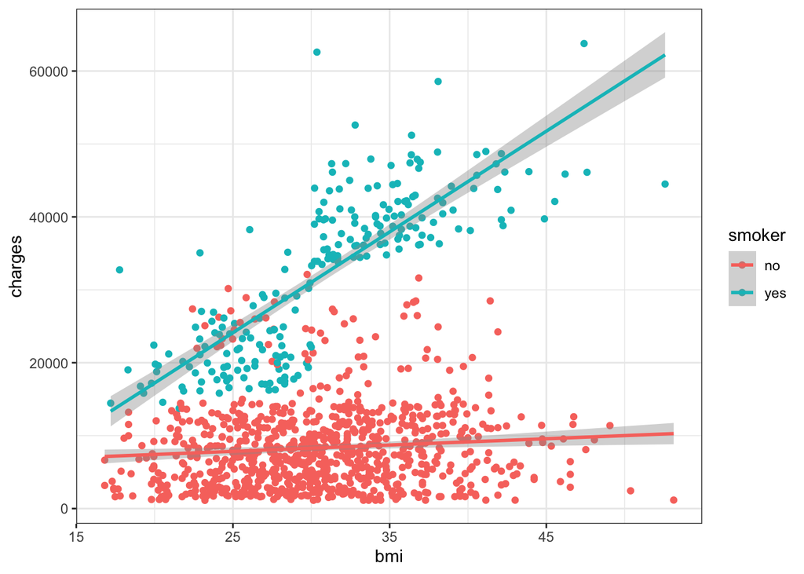

```r
insurance_train %>% ggplot(aes(bmi, charges, col=smoker)) + geom_point() + geom_smooth(method="lm") + theme_bw()
```

We see that the effect of `bmi` in insurance `charges` is more acute for smokers that for non-smokers. That means that there is an **interaction effect** of `smoker` in the relationship between `bmi` and `charges`. Sometimes we say that `smoker` **moderates** the relationship between `bmi` and `charges`.

We account for interaction terms adding a `bmi*smoker` term in the formula, and deleting `bmi` and `smoker`:

```r
mod04 <- train(charges ~ sex + region + poly(age, 2) + bmi*smoker + children, method="lm", insurance_train, preProcess=c("center", "scale"))
```

Let’s see how the model looks like. We see that by adding `bmi*smoker` we have incorporated `bmi`, `smoker` and the interaction term `bmi:smoker`. We see that this interaction effect is significant in the regression equation.

```r
summary(mod04$finalModel)
```

```
##
## Call:
## lm(formula = .outcome ~ ., data = dat)
##
## Residuals:
##    Min     1Q Median     3Q    Max
## -14294  -1543  -1133   -860  31014
##
## Coefficients:
##                 Estimate Std. Error t value Pr(>|t|)
## (Intercept)      13229.2      140.9  93.883  < 2e-16 ***
## sexmale           -268.8      141.9  -1.894 0.058439 .
## regionnorthwest   -419.7      174.5  -2.405 0.016359 *
## regionsoutheast   -575.6      182.3  -3.157 0.001637 **
## regionsouthwest   -583.6      175.0  -3.334 0.000884 ***
## `poly(age, 2)1`   3587.7      142.5  25.181  < 2e-16 ***
## `poly(age, 2)2`    547.4      148.5   3.687 0.000239 ***
## bmi                155.5      166.4   0.934 0.350279
## smokeryes        -7618.2      699.4 -10.893  < 2e-16 ***
## children           685.6      148.6   4.613 4.45e-06 ***
## `bmi:smokeryes`  17897.9      704.8  25.393  < 2e-16 ***
## ---
## Signif. codes:  0 '***' 0.001 '**' 0.01 '*' 0.05 '.' 0.1 ' ' 1
##
## Residual standard error: 4614 on 1061 degrees of freedom
## Multiple R-squared:  0.8539, Adjusted R-squared:  0.8525
## F-statistic: 620.1 on 10 and 1061 DF,  p-value: < 2.2e-16
```

We can see that the prediction on the train set has significantly improved:

```r
pr_train04 <- predict(mod04, insurance_train)
postResample(pred = pr_train04, insurance_train$charges)
```

```
##         RMSE     Rsquared          MAE
## 4589.9306331    0.8538883 2731.6204299
```

## 2.5 A final model

The model can still be improved by replacing `bmi` by `bmi30`:

```r
mod05 <- train(charges ~ sex + region + poly(age, 2) + bmi30*smoker + children, method="lm", insurance_train, preProcess=c("center", "scale"))
```

Now we attain the best prediction scores on the train set.

```r
pr_train05 <- predict(mod05, insurance_train)
postResample(pred = pr_train05, insurance_train$charges)
```

```
##         RMSE     Rsquared          MAE
## 4234.6400398    0.8756328 2310.1682232
```

Let’s compare the observed and predicted charges for this model. We have identified obese patients:

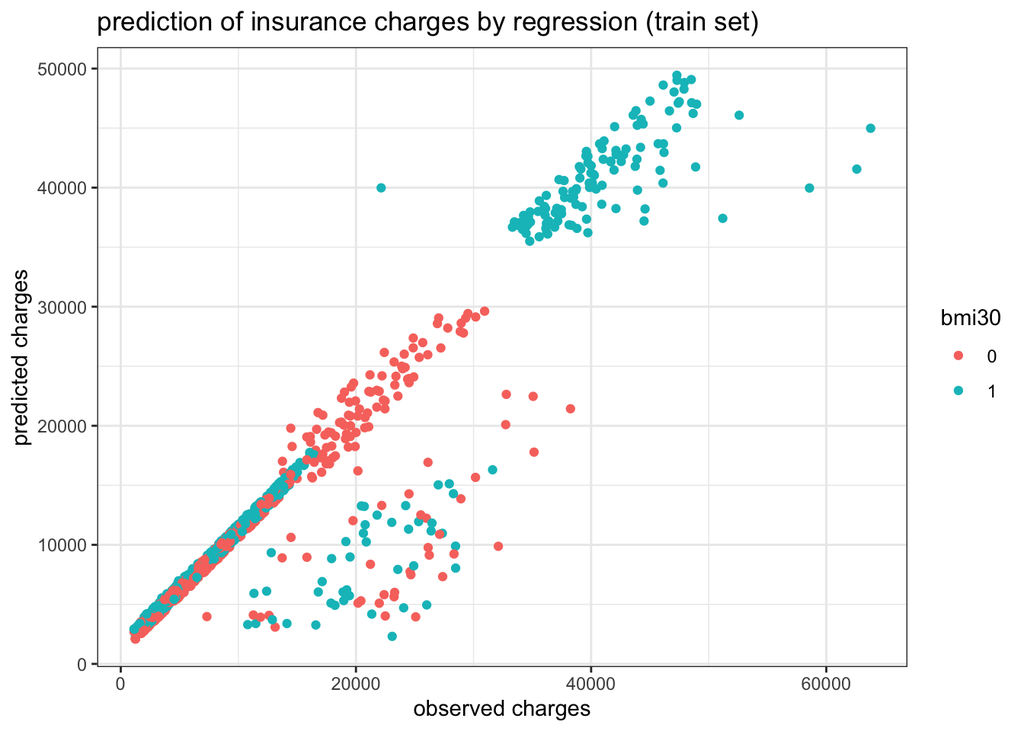

```r
insurance_train <- insurance_train %>% mutate(pred=pr_train05)
insurance_train %>% ggplot(aes(charges, pred, col=bmi30)) + geom_point() + theme_bw() + labs(title="prediction of insurance charges by regression (train set)", x= "observed charges", y="predicted charges")
```

There is a subset of observations with higher charges than expected. This subset cannot be identified with the available data.

## 2.6 Predicting the test set

Finally, we can apply our model to the test set:

```r
pr_test05 <- predict(mod05, insurance_test)
```

The predicition for the test set is slightly worse than for the train set:

```r
postResample(pred = pr_train05, insurance_train$charges)
```

```
##         RMSE     Rsquared          MAE
## 4234.6400398    0.8756328 2310.1682232
```

```r
postResample(pred = pr_test05, insurance_test$charges)
```

```
##         RMSE     Rsquared          MAE
## 5237.8876700    0.8255337 2718.1674727
```

And we observed a similar pattern than in the train test for the observed vs predicted plot:

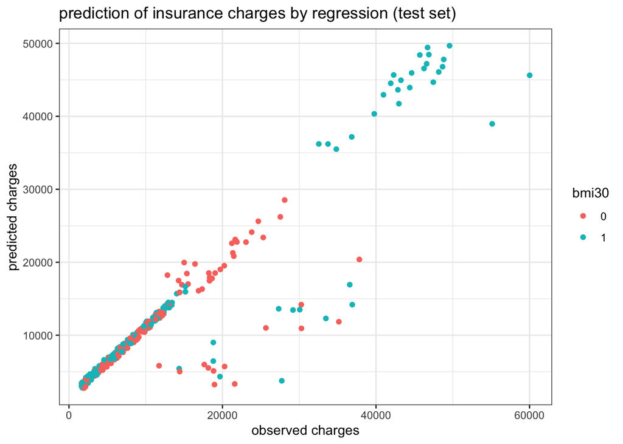

```r
insurance_test <- insurance_test %>% mutate(pred=pr_test05)
insurance_test %>% ggplot(aes(charges, pred, col=bmi30)) + geom_point() + theme_bw() + labs(title="prediction of insurance charges by regression (test set)", x= "observed charges", y="predicted charges")
```